# GLMM Analysis Report

## Methods

Model was fitted using **lme4::lmer**.

Family: **gaussian**

Sample size used in this fit: **27 subjects**, **322 observations**.

## Model Fitting Diagnostics

This section reports diagnostics captured automatically at fit time and should be reviewed before interpreting the results below. A singular fit, a non-convergence message, or fitting warnings do not necessarily invalidate a model, but they do mean its estimates (particularly variance components) should be interpreted with caution.

| Check | Result |
| --- | --- |
| Singular fit | NO |
| Convergence | OK |

### Warnings raised during model fitting

*No warnings were raised while fitting this model.*

## Results

### Model Summary

Full summary output of the fitted model, as printed by R.

```
## Linear mixed model fit by REML. t-tests use Satterthwaite's method ['lmerModLmerTest']
## Formula: weight ~ treatment + sex + litsize + treatment * sex + (1 | litter)
##    Data: df
##
## REML criterion at convergence: 401.1
##
## Scaled residuals:
##     Min      1Q  Median      3Q     Max
## -7.4725 -0.5001  0.0291  0.5735  3.0096
##
## Random effects:
##  Groups   Name        Variance Std.Dev.
##  litter   (Intercept) 0.09652  0.3107
##  Residual             0.16349  0.4043
## Number of obs: 322, groups:  litter, 27
##
## Fixed effects:
##                        Estimate Std. Error        df t value Pr(>|t|)
## (Intercept)             7.91165    0.27496  33.70992  28.773  < 2e-16 ***
## treatmentHigh          -0.79903    0.19429  32.88474  -4.112 0.000245 ***
## treatmentLow           -0.38317    0.15967  29.56842  -2.400 0.022919 *
## sexMale                 0.41169    0.07315 295.30143   5.628 4.24e-08 ***
## litsize                -0.12838    0.01875  31.79751  -6.846 9.94e-08 ***
## treatmentHigh:sexMale  -0.10702    0.13176 303.74417  -0.812 0.417291
## treatmentLow:sexMale   -0.08387    0.10568 298.58691  -0.794 0.428077
## ---
## Signif. codes:  0 '***' 0.001 '**' 0.01 '*' 0.05 '.' 0.1 ' ' 1
##
## Correlation of Fixed Effects:
##             (Intr) trtmnH trtmnL sexMal litsiz trtH:M
## treatmntHgh -0.581
## treatmentLw -0.336  0.434
## sexMale     -0.155  0.221  0.269
## litsize     -0.910  0.372  0.045 -0.001
## trtmntHgh:M  0.105 -0.360 -0.150 -0.555 -0.020
## trtmntLw:sM  0.141 -0.166 -0.345 -0.692 -0.036  0.385
```

### Random Effects

Both the **variance** (σ²) and the **standard deviation** (σ) of each random-effect term are shown. The residual row is the within-group (observation-level) variance.

Random-effects variance components

| Group | Effect | Variance | Std.Dev. |
| --- | --- | --- | --- |
| litter | (Intercept) | 0.09652 | 0.3107 |
| Residual | (Residual) | 0.16350 | 0.4043 |

### Fixed Effects

Estimate

Std. Error

df

t value

Pr(>|t|)

(Intercept)

7.912

0.275

34

28.773

< 1e-04

***

treatmentHigh

-0.799

0.194

33

-4.112

0.000245

***

treatmentLow

-0.383

0.160

30

-2.400

0.022919

sexMale

0.412

0.073

295

5.628

< 1e-04

***

litsize

-0.128

0.019

32

-6.846

< 1e-04

***

treatmentHigh:sexMale

-0.107

0.132

304

-0.812

0.417291

treatmentLow:sexMale

-0.084

0.106

299

-0.794

0.428077

### ANOVA (Type III)

```
## Type III Analysis of Variance Table with Satterthwaite's method
##               Sum Sq Mean Sq NumDF   DenDF F value    Pr(>F)
## treatment     3.7568  1.8784     2  24.279 11.4895 0.0003081 ***
## sex           7.6826  7.6826     1 302.900 46.9915 4.001e-11 ***
## litsize       7.6619  7.6619     1  31.798 46.8652 9.937e-08 ***
## treatment:sex 0.1522  0.0761     2 302.303  0.4656 0.6282199
## ---
## Signif. codes:  0 '***' 0.001 '**' 0.01 '*' 0.05 '.' 0.1 ' ' 1
```

### Model Performance

Variance explained and clustering (R2, ICC)

| Metric | Value |
| --- | --- |
| R2 marginal (fixed effects only) | 0.4197 |
| R2 conditional (fixed + random effects) | 0.6351 |
| ICC (adjusted) | 0.3712 |
| ICC (unadjusted) | 0.2154 |

Information criteria and error measures

| Metric | Value |
| --- | --- |
| AIC | 419.1000 |
| AICc | 419.7000 |
| BIC | 453.1000 |
| RMSE | 0.3872 |
| Sigma | 0.4043 |

**How to read these measures**

- **R2 marginal**: proportion of variance explained by the fixed effects alone.
- **R2 conditional**: proportion of variance explained by the fixed and random effects together.
- **ICC**: proportion of the total (non-fixed-effect) variance attributable to differences between groups/subjects; higher values mean observations within the same group are more alike.
- This model was fitted by REML: AIC/BIC are only comparable between models with identical fixed effects. Refit by ML to compare models with different fixed effects.

### DHARMa Residual Diagnostics

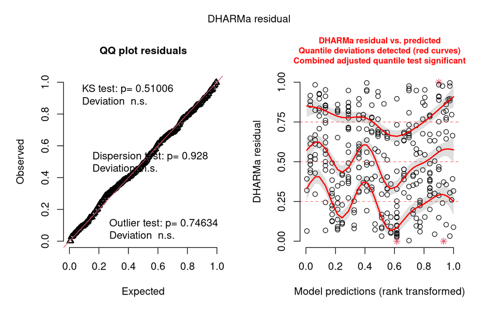